# Obligatorio de Taller de Aprendizaje Automático

### 3.2 PCAMix

```r
# Separamos numéricas de factores
separacion <- splitmix(allRestaurant)
cuantitativas <- separacion$X.quanti
cualitativas <- separacion$X.quali

#PCAmix
restMixPCA <- PCAmix(cuantitativas, cualitativas, rename.level = TRUE, graph = FALSE, ndim = 31)

# Contribución a la varianza
restMixPCA$eig # el 90% de la varianza se acumula en el componente 18
```

```
##          Eigenvalue   Proportion Cumulative
## dim 1  4.764096e+00 1.588032e+01   15.88032
## dim 2  3.253159e+00 1.084386e+01   26.72418
## dim 3  2.710643e+00 9.035478e+00   35.75966
## dim 4  1.947226e+00 6.490754e+00   42.25042
## dim 5  1.769087e+00 5.896957e+00   48.14737
## dim 6  1.668620e+00 5.562068e+00   53.70944
## dim 7  1.387468e+00 4.624894e+00   58.33433
## dim 8  1.352924e+00 4.509747e+00   62.84408
## dim 9  1.166429e+00 3.888098e+00   66.73218
## dim 10 1.100701e+00 3.669002e+00   70.40118
## dim 11 1.027183e+00 3.423943e+00   73.82512
## dim 12 1.005899e+00 3.352995e+00   77.17812
## dim 13 9.413714e-01 3.137905e+00   80.31602
## dim 14 7.551293e-01 2.517098e+00   82.83312
## dim 15 7.481054e-01 2.493685e+00   85.32681
## dim 16 6.698799e-01 2.232933e+00   87.55974
## dim 17 6.070104e-01 2.023368e+00   89.58311
## dim 18 5.883692e-01 1.961231e+00   91.54434
## dim 19 5.357638e-01 1.785879e+00   93.33022
## dim 20 5.094341e-01 1.698114e+00   95.02833
## dim 21 4.441240e-01 1.480413e+00   96.50874
## dim 22 3.286061e-01 1.095354e+00   97.60410
## dim 23 2.218484e-01 7.394947e-01   98.34359
## dim 24 1.845453e-01 6.151511e-01   98.95874
## dim 25 1.796517e-01 5.988391e-01   99.55758
## dim 26 1.290830e-01 4.302767e-01   99.98786
## dim 27 2.771925e-03 9.239750e-03   99.99710
## dim 28 6.371451e-04 2.123817e-03   99.99922
## dim 29 2.010499e-04 6.701663e-04   99.99989
## dim 30 3.193296e-05 1.064432e-04  100.00000
```

```r
#Se corre nuevamente para 18 dimensiones que es donde se acumula más del 90% de la varianza
restMixPCA <- PCAmix(cuantitativas, cualitativas, rename.level = TRUE, graph = FALSE, ndim = 18)

allRestScores <- data.frame(restMixPCA$scores.stand)
head(allRestScores)
```

```
##        dim.1       dim.2      dim.3      dim.4      dim.5      dim.6
## 1 -0.2483226  2.04430901 -0.3100050 -1.0525738 -0.9782279 -0.6354863
## 2 -0.3246526 -0.78250272  1.3380382  0.5631232  0.4403474  0.3389796
## 3  0.3744839  0.01072688  1.1548716 -0.6834481  0.7898966  1.0106045
## 4 -1.5036258  0.68211530  0.7892233  0.2522273 -0.8161023 -1.0149799
## 5 -1.4989064  0.08680828  0.5118882 -0.3527573 -0.7007179 -0.7232917
## 6  0.6235774 -1.76202773 -2.3538695  0.3026271  1.3261191  0.9280145
##        dim.7       dim.8      dim.9     dim.10      dim.11     dim.12
## 1 -0.4930942  0.20809548 -0.7968916 -0.2856851  2.84802175 -0.3271224
## 2 -0.9701697  0.25815822  1.1389234  1.6344251  0.23444654  0.5091470
## 3 -1.3965837  1.23381164 -0.3365609  1.2209931 -1.32531233 -1.4455599
## 4  0.1628054 -0.91662081  3.3206244 -2.6014635 -0.07395479 -1.5878078
## 5 -1.0945436 -0.02348772  0.1520536  0.2586313 -0.69314580 -0.4207475
## 6 -0.1487718 -0.58118271 -0.9342950 -0.5482242 -0.80784112 -1.1894193
##        dim.13      dim.14     dim.15     dim.16      dim.17       dim.18
## 1  1.14013376 -0.61872694 -1.2029904  0.8085901 -0.09096777 -0.163848647
## 2 -0.21663386  0.10985505  0.2326049 -1.6593202  1.73200716 -0.760867901
## 3 -1.39670019 -1.95199285  0.9196379  0.7163605  2.45066936  0.413392412
## 4 -0.66924928  1.68208927 -0.4599555 -0.3860200  1.32673834 -0.887768788
## 5 -0.74370026  0.06858424  0.1252666 -0.1227620 -1.84379645 -0.001428818
## 6  0.01271745 -0.14278092  1.1627062 -0.1922536 -0.07082232  0.908201711
```

### 3.2 Distancia de Gower

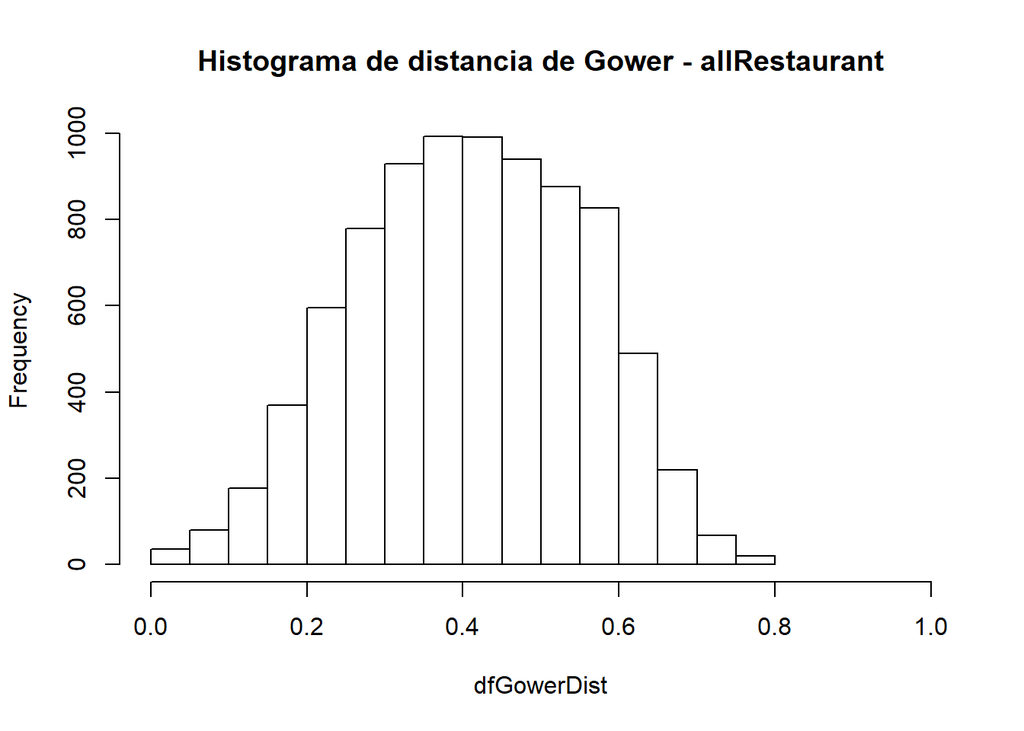

```r
dfGowerDist <- daisy(allRestaurant, metric = "gower")

#Generar el histograma dfGowerDist
hist(dfGowerDist, xlim = range(0.0,1.0), main = "Histograma de distancia de Gower - allRestaurant")
```

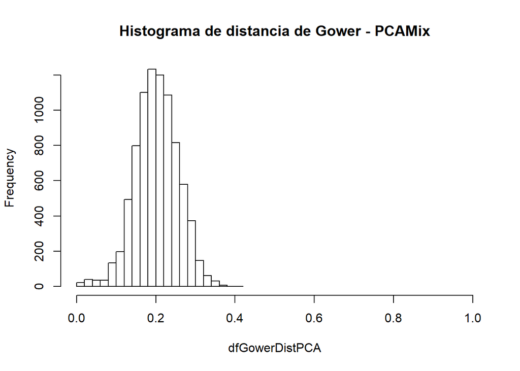

```r
dfGowerDistPCA <- daisy(allRestScores, metric = "gower")

#Generar el histograma dfGowerDist
hist(dfGowerDistPCA, xlim = range(0.0,1.0), main = "Histograma de distancia de Gower - PCAMix")
```

## 4. Modelado y Evaluación

5.1 ¿Qué variables pre-seleccionaría en base al análisis funcional y estadístico? Una vez realizado el análisis anterior en relación a la transformación, eliminación y creación de nuevas variables decidimos quedarnos con todas las que se encuentran en la nueva tabla de datos

```r
str(allRestaurant)
```

```
## 'data.frame':    130 obs. of  19 variables:
##  $ placeID      : int  134999 132825 135106 132667 132613 135040 132732 132875 132609 135082 ...
##  $ distPoint1   : num  210.749 0.349 1.076 205.827 205.639 ...
##  $ distPoint2   : num  4.1 206.5 205.8 86.4 86.4 ...
##  $ distPoint3   : num  85.77 207.17 206.39 1.72 1.91 ...
##  $ classCity    : Factor w/ 3 levels "A","B","C": 2 1 1 3 3 1 3 1 3 1 ...
##  $ isSmoking    : logi  FALSE FALSE TRUE FALSE TRUE FALSE ...
##  $ foodCount    : num  1 1 1 1 1 10 1 1 1 10 ...
##  $ TypeCuisine  : Factor w/ 10 levels "American","Asian",..: 2 8 8 5 8 10 8 2 6 10 ...
##  $ hasParking   : logi  FALSE FALSE FALSE FALSE TRUE TRUE ...
##  $ payCount     : num  10 1 3 1 1 3 1 5 1 1 ...
##  $ rating       : num  1.6 1.28 1.2 1.25 1.17 ...
##  $ foodRating   : num  1.6 1.34 1.2 2 1.33 ...
##  $ serviceRating: num  1.6 0.938 1.2 1.25 1 ...
##  $ area         : Factor w/ 2 levels "closed","open": 1 2 2 1 1 1 2 2 1 1 ...
##  $ Rambience    : Factor w/ 2 levels "familiar","quiet": 1 1 1 1 1 1 1 1 2 1 ...
##  $ price        : Factor w/ 3 levels "high","low","medium": 3 2 3 2 3 1 2 1 2 3 ...
##  $ accessibility: Factor w/ 3 levels "completely","no_accessibility",..: 2 1 3 1 1 2 1 2 1 2 ...
##  $ dress_code   : Factor w/ 3 levels "casual","formal",..: 3 3 3 3 3 3 1 3 3 3 ...
##  $ alcohol      : Factor w/ 3 levels "Full_Bar","No_Alcohol_Served",..: 2 2 3 2 2 3 2 3 2 2 ...
```

### 4.2 Estime al menos dos modelos (usando diferentes algoritmos y/o variables), compárelos (en base a criterios estadísticos y funcionales) y seleccione el que entienda más adecuado.

Utilizaremos los algoritmos de hclust como clustering aglomerativo y diana como clustering divisivo. Para calcular las distancias de Gower utilizamos Daisy ya que tenemos variables mixtas dentro de la tabla de datos. Adicionalmente utilizaremos PCAmixed para calcular las mismas utilizando como dimensión la cantidad de componentes principales que acumulan el 90% de la varianza.

#### 4.2.1 Modelo - Diana

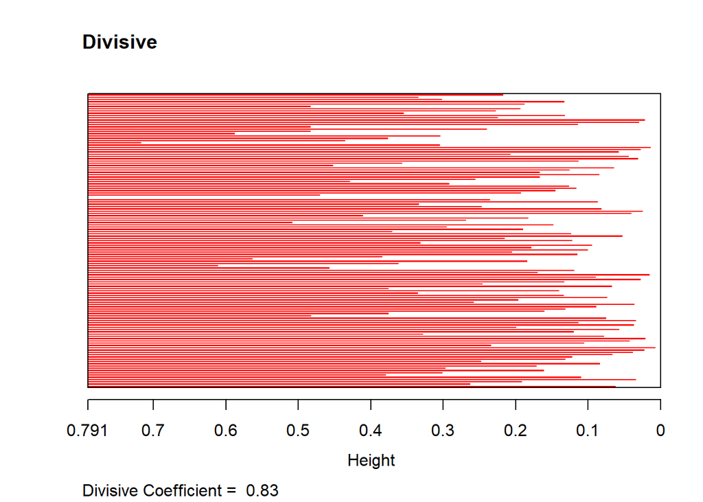

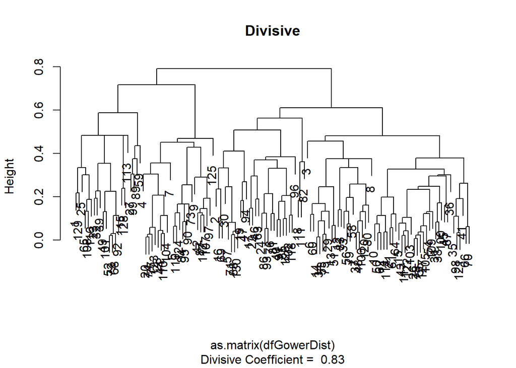

```r
clustDianaDiv <- diana(as.matrix(dfGowerDist),diss = TRUE, keep.diss = TRUE)
plot(clustDianaDiv, main = "Divisive")
```

**Análisis del Elbow**

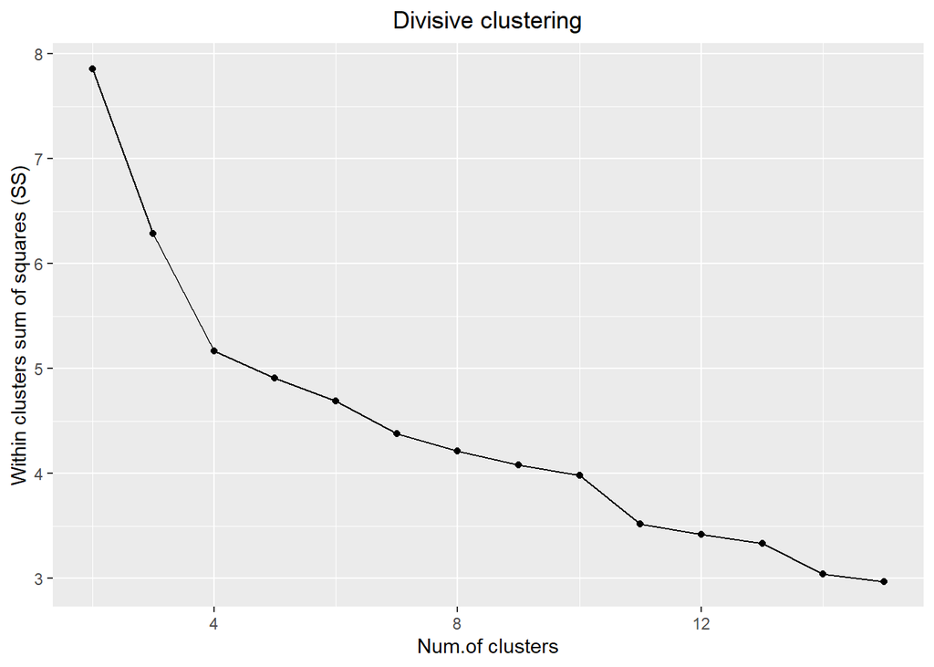

```r
ggplot(data = data.frame(t(cstats.table(dfGowerDist, clustDianaDiv, 15))),
  aes(x=cluster.number, y=within.cluster.ss)) +
  geom_point()+
  geom_line()+
  ggtitle("Divisive clustering") +
  labs(x = "Num.of clusters", y = "Within clusters sum of squares (SS)") +
  theme(plot.title = element_text(hjust = 0.5))
```

**Análisis de la Silueta**

En función de los resultados obtenidos en el codo anterior se determina K optimo igual 4

```
##   cluster size ave.sil.width
## 1       1   21          0.31
## 2       2   31          0.26
## 3       3   53          0.33
## 4       4   25          0.38
```

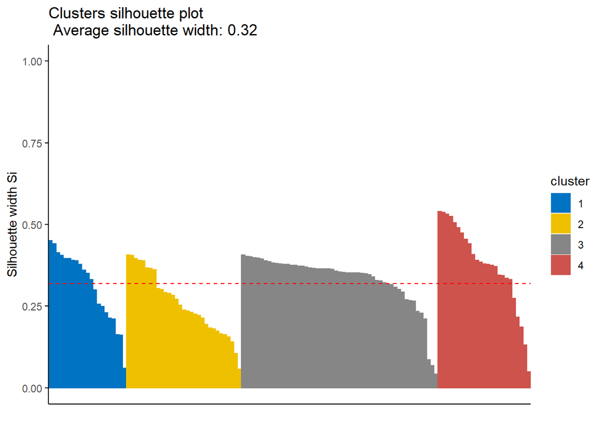

```r
clusDiana <- eclust(x = dfGowerDist, FUNcluster = "diana", k = 4, seed = 123,
                      hc_metric = "euclidean", nstart = 50, graph = FALSE)
fviz_silhouette(sil.obj = clusDiana, print.summary = TRUE, palette = "jco",
                ggtheme = theme_classic())
```

#### 4.2.2 Modelo: Diana con PCAMix

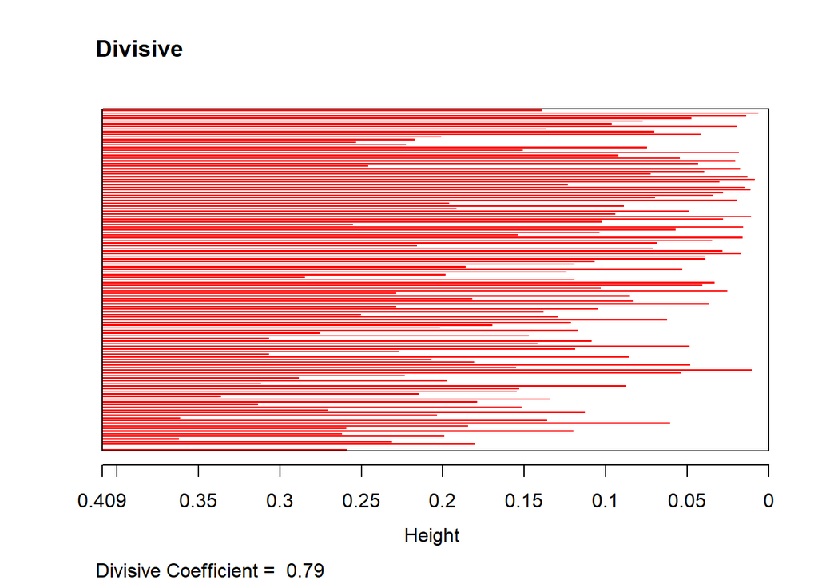

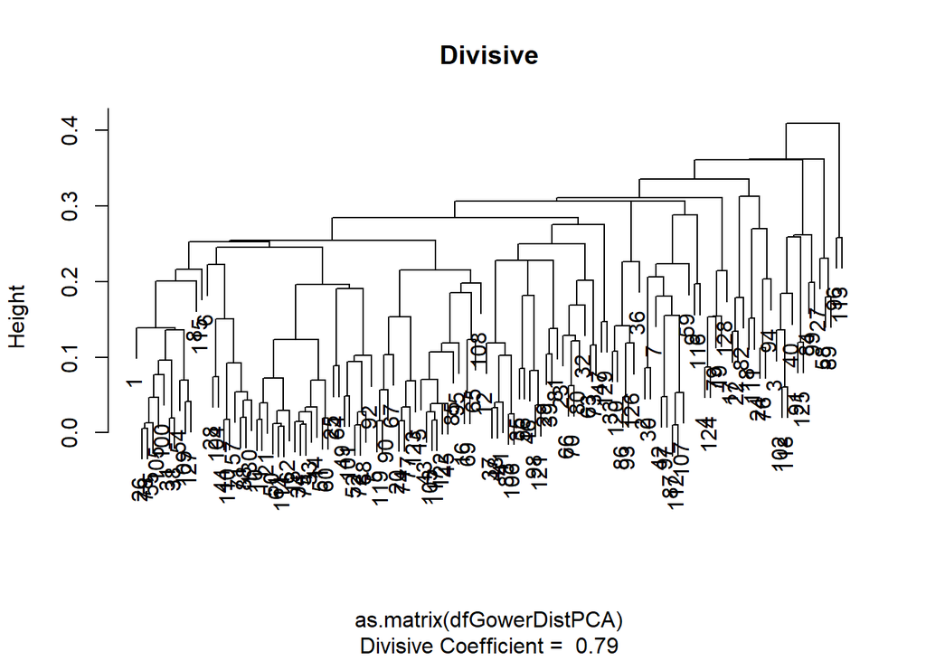

```r
clustDianaPCAmix <- diana(as.matrix(dfGowerDistPCA),diss = TRUE, keep.diss = TRUE)
plot(clustDianaPCAmix, main = "Divisive")
```

**Análisis del Elbow**

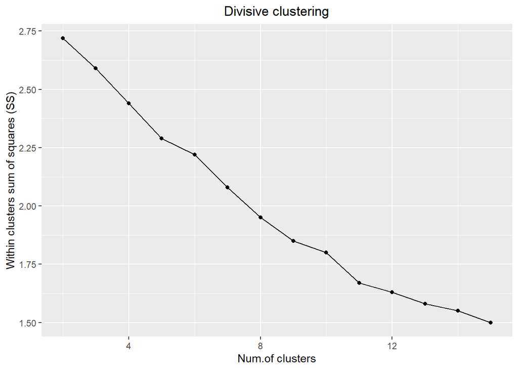

```r
ggplot(data = data.frame(t(cstats.table(dfGowerDistPCA, clustDianaPCAmix, 15))),
  aes(x=cluster.number, y=within.cluster.ss)) +
  geom_point()+
  geom_line()+
  ggtitle("Divisive clustering") +
  labs(x = "Num.of clusters", y = "Within clusters sum of squares (SS)") +
  theme(plot.title = element_text(hjust = 0.5))
```

**Análisis de la Silueta** En función de los resultados obtenidos en el codo anterior se determina K optimo igual 5

```
##   cluster size ave.sil.width
## 1       1   36          0.10
## 2       2   21          0.09
## 3       3   63          0.20
## 4       4    8          0.14
## 5       5    2          0.31
```

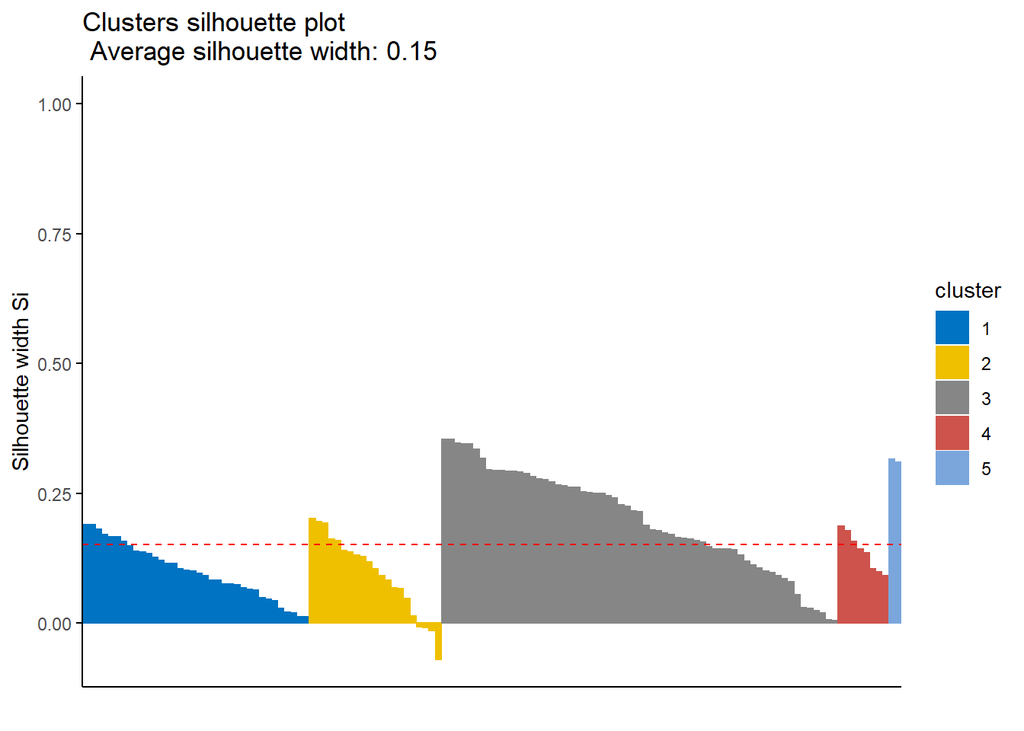

```r
clusDianaPCA <- eclust(x = dfGowerDistPCA, FUNcluster = "diana", k = 5, seed = 123,
                      hc_metric = "euclidean", nstart = 50, graph = FALSE)
fviz_silhouette(sil.obj = clusDianaPCA, print.summary = TRUE, palette = "jco",
                ggtheme = theme_classic())
```

#### 4.2.3 - Modelo: HCLUST

Modelo aglomerativo HCLUST

**HCLUST: Definición del método** Realizaremos una corrida para cada metodo de hclust para identificar cual es el que tiene mayor numero de correlacion según los metodos posibles.

```r
# Metodo hclust (Hierarchical Agglomerative Clustering)
H1=hclust(dfGowerDist,method='average')
H2=hclust(dfGowerDist,method='complete')
H3=hclust(dfGowerDist,method='ward.D')
H4=hclust(dfGowerDist,method='single')

#Obteniendo el coheficiente de correlación para cada metodo
C1=cophenetic(H1)
C2=cophenetic(H2)
C3=cophenetic(H3)
C4=cophenetic(H4)


print(paste("method: average =",cor(dfGowerDist,C1)))
```

```
## [1] "method: average = 0.815914002917422"
```

```r
print(paste("method: complete =",cor(dfGowerDist,C2)))
```

```
## [1] "method: complete = 0.792568517638006"
```

```r
print(paste("method: ward.D =",cor(dfGowerDist,C3)))
```

```
## [1] "method: ward.D = 0.746735860376836"
```

```r
print(paste("method: single =",cor(dfGowerDist,C4)))
```

```
## [1] "method: single = 0.726837100652695"
```

El metodo que con mayor cohefiente de correlacion fue el “average” con un 0.81 por tanto utilizaremos este metodo para el modelado.

**Modelo: hclust** A partir del metodo definido en el epigrafe anterior se realiza la corrida del modelo

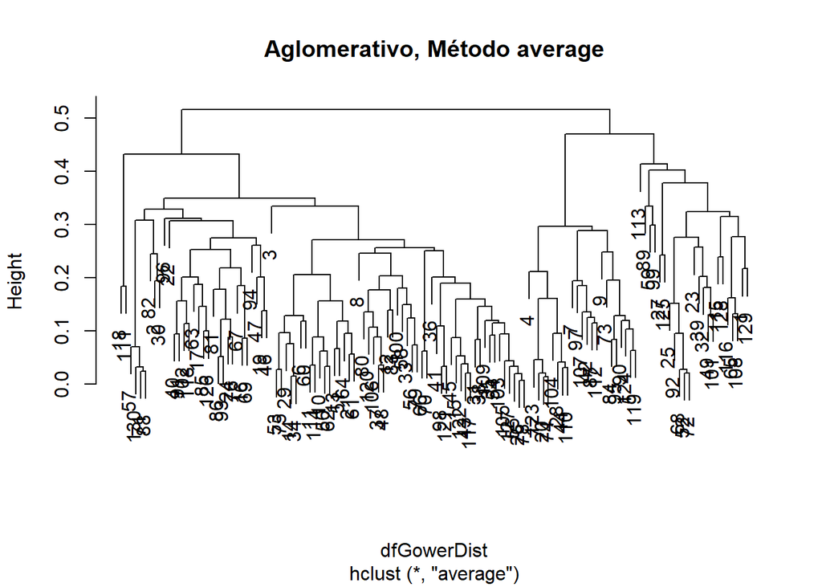

```r
clustHclustAggl <- hclust(dfGowerDist, method = "average")

plot(clustHclustAggl, main = "Aglomerativo, Método average")
```

**Análisis del Elbow**

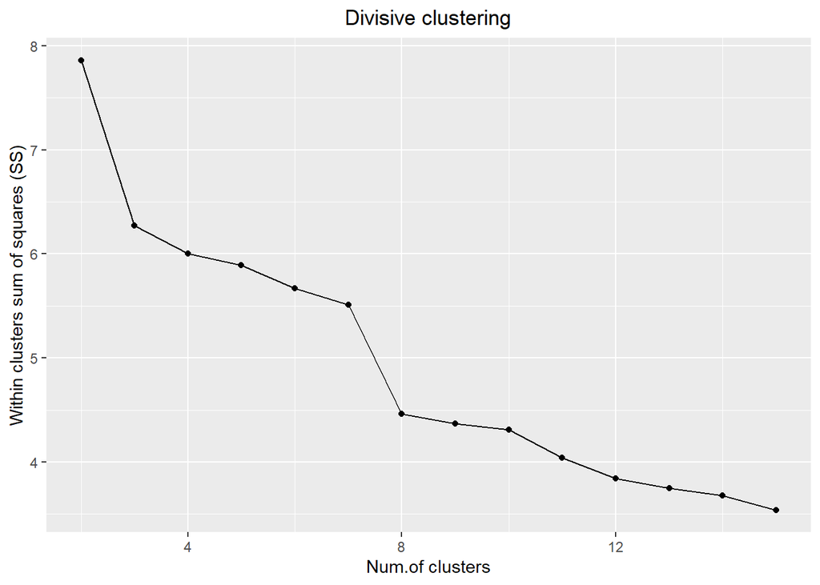

```r
ggplot(data = data.frame(t(cstats.table(dfGowerDist, clustHclustAggl, 15))),
  aes(x=cluster.number, y=within.cluster.ss)) +
  geom_point()+
  geom_line()+
  ggtitle("Divisive clustering") +
  labs(x = "Num.of clusters", y = "Within clusters sum of squares (SS)") +
  theme(plot.title = element_text(hjust = 0.5))
```

```
##   cluster size ave.sil.width
## 1       1   23          0.29
## 2       2   33          0.23
## 3       3   23          0.39
## 4       4   51          0.35
```

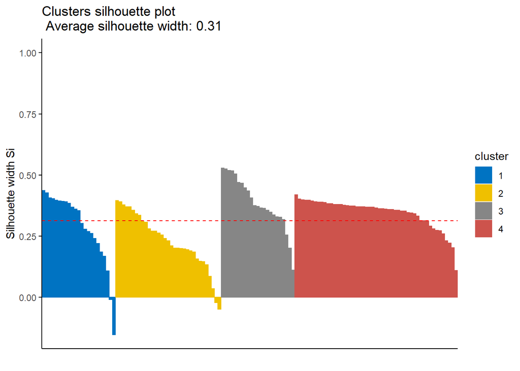

```r
clusHclust <- eclust(x = dfGowerDist, FUNcluster = "hclust", k = 4, seed = 123,
                      hc_metric = "euclidean", nstart = 50, graph = FALSE)
fviz_silhouette(sil.obj = clusHclust, print.summary = TRUE, palette = "jco",
                ggtheme = theme_classic())
```

#### 4.2.4 Modelo: hclust (PCAMix)

A partir del metodo definido en el epígrafe anterior se realiza la corrida del modelo utilizando PCAMix

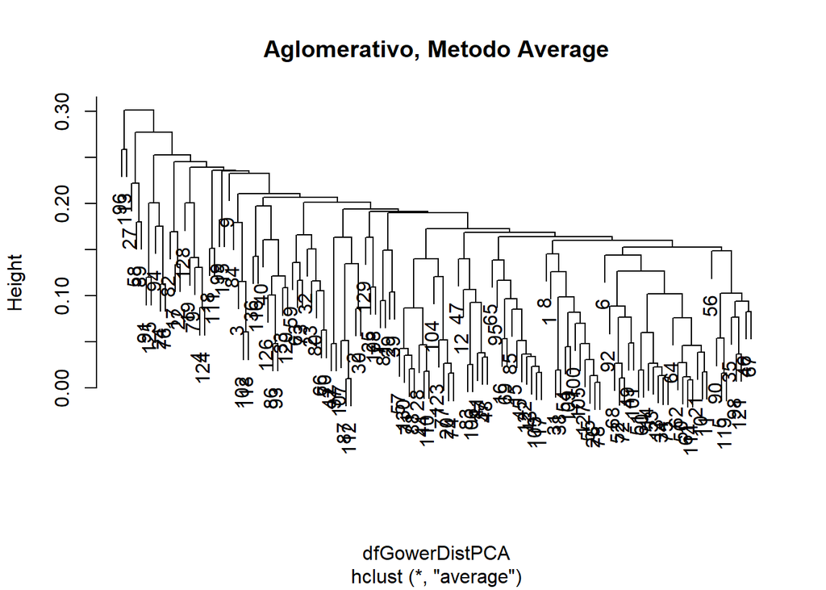

```r
clustHclustAgglPCA <- hclust(dfGowerDistPCA, method = "average")

plot(clustHclustAgglPCA, main = "Aglomerativo, Metodo Average")
```

**Análisis del Elbow**

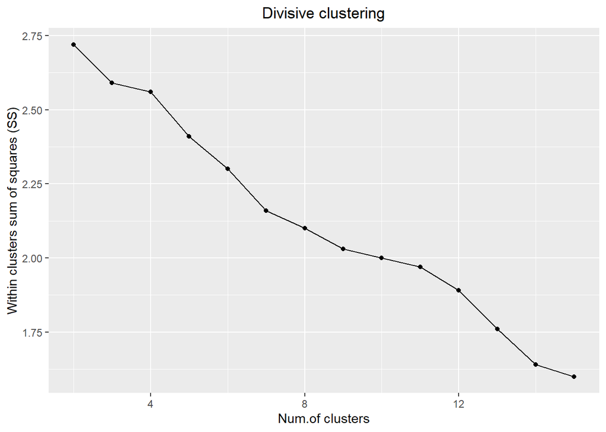

```r
ggplot(data = data.frame(t(cstats.table(dfGowerDistPCA, clustHclustAgglPCA, 15))),
  aes(x=cluster.number, y=within.cluster.ss)) +
  geom_point()+
  geom_line()+
  ggtitle("Divisive clustering") +
  labs(x = "Num.of clusters", y = "Within clusters sum of squares (SS)") +
  theme(plot.title = element_text(hjust = 0.5))
```

**Análisis de la Silueta** En función de los resultados obtenidos en el codo anterior se determina K optimo igual 3

```
##   cluster size ave.sil.width
## 1       1   48          0.07
## 2       2   29          0.15
## 3       3   53          0.22
```

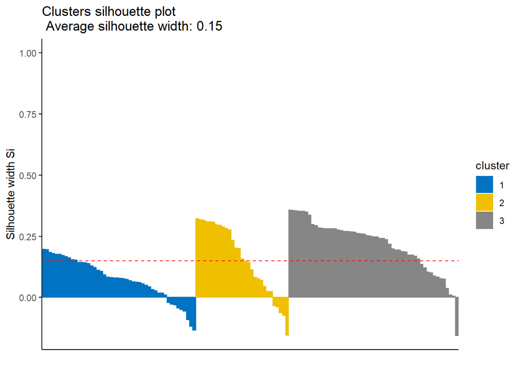

```r
clusHclustPCA <- eclust(x = dfGowerDistPCA, FUNcluster = "hclust", k = 3, seed = 123,
                      hc_metric = "euclidean", nstart = 50, graph = FALSE)
fviz_silhouette(sil.obj = clusHclustPCA, print.summary = TRUE, palette = "jco",
                ggtheme = theme_classic())
```

### 4.3 Poda del arbol y asociación de cluster al dataset

A partir de los resultados de la silueta obtenidos para Diana y Hclust con y sin PCAMix concluimos que el mejor modelo es Diana sin PCAMix para K=4 obteniendo una silueta de 0.32.

```r
groups <- as.factor(cutree(clustDianaDiv, k=4))
summary(groups)
```

```
##  1  2  3  4
## 22 30 54 24
```

Se le agregara al dataset los nombres de los restaurantes

```r
allRestaurant$cluster <- groups

restName <- geoplaces[,c("placeID","name")]
allRestaurant <- left_join(x = allRestaurant,y = restName,by = "placeID",all = TRUE)
head(allRestaurant)
```

```
##   placeID  distPoint1 distPoint2 distPoint3 classCity isSmoking foodCount
## 1  134999 210.7491874   4.099599  85.770393         B     FALSE         1
## 2  132825   0.3488594 206.499412 207.169042         A     FALSE         1
## 3  135106   1.0762984 205.762946 206.388126         A      TRUE         1
## 4  132667 205.8273963  86.362182   1.716889         C     FALSE         1
## 5  132613 205.6389491  86.359610   1.905332         C      TRUE         1
## 6  135040   1.8348958 204.994784 205.723112         A     FALSE        10
##   TypeCuisine hasParking payCount   rating foodRating serviceRating   area
## 1       Asian      FALSE       10 1.600000   1.600000        1.6000 closed
## 2     Mexican      FALSE        1 1.281250   1.343750        0.9375   open
## 3     Mexican      FALSE        3 1.200000   1.200000        1.2000   open
## 4     Europea      FALSE        1 1.250000   2.000000        1.2500 closed
## 5     Mexican       TRUE        1 1.166667   1.333333        1.0000 closed
## 6    SIN DATO       TRUE        3 0.250000   0.250000        0.2500 closed
##   Rambience  price    accessibility dress_code           alcohol cluster
## 1  familiar medium no_accessibility   informal No_Alcohol_Served       1
## 2  familiar    low       completely   informal No_Alcohol_Served       2
## 3  familiar medium        partially   informal         Wine-Beer       3
## 4  familiar    low       completely   informal No_Alcohol_Served       4
## 5  familiar medium       completely   informal No_Alcohol_Served       4
## 6  familiar   high no_accessibility   informal         Wine-Beer       3
##                             name
## 1                Kiku Cuernavaca
## 2                puesto de tacos
## 3     El Rincón de San Francisco
## 4 little pizza Emilio Portes Gil
## 5                  carnitas_mata
## 6       Restaurant los Compadres
```

### 4.3 Caracterice y describa los resultados a los cuales se arribaron en el caso anterior, desde el punto de vista del negocio.

Consideramos que por el resultado obtenido en el coeficiente de la silueta en base al K optimo resultante de la gráfica “elbow” no es lo suficientemente bueno. En la corrida anterior con los tipos de comidas abiertos como varibales obtuvimos un coeficiente de 0,45. Sin embargo a nivel de interpretación de resultados no vemos la utilidad de tener un cluster formado por registros con atributos “otros” cuando en realidad se trató de una correccion a los datos por la forma de exposición. Se muestra gráficamente dentro del dendograma la distribución de los 4 clusters

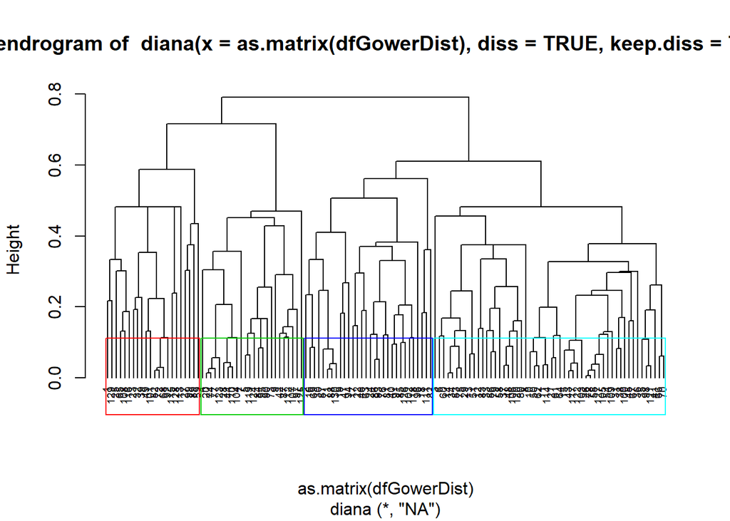

```r
pltree(clustDianaDiv, hang=-1, cex = 0.6)
rect.hclust(clustDianaDiv, k = 4, border = 2:10)
```

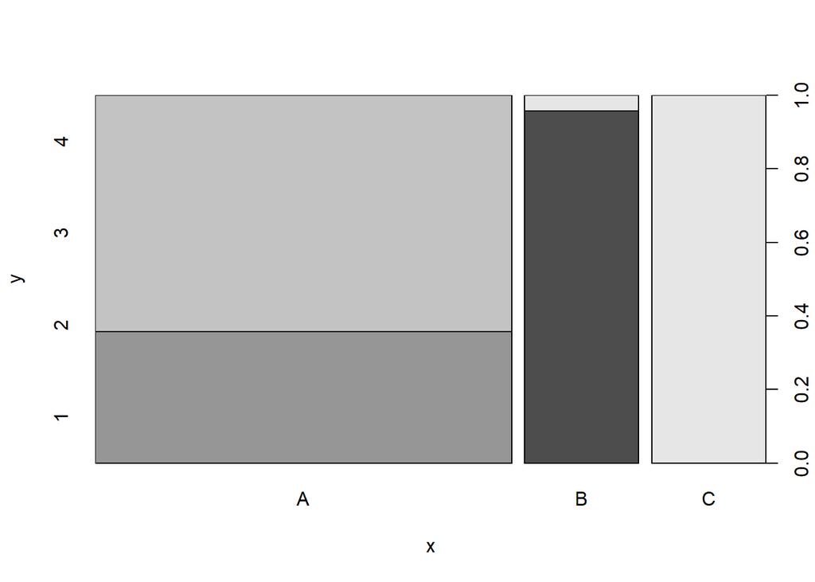

```r
# classCity
# foodCount
# TypeCuisine
# payCount
#cluster

plot(allRestaurant$classCity,allRestaurant$cluster)
```

```r
# library(Lock5Data)
# plot(Happiness,LifeExpectancy,pch=19,col="red")
```

De la gráfica se concluye que los datos quedaron fuertemente clusterizados por la ciudad. Dentro de la ciudad A por el volumen de datos en relación a las dos restantes se formaron dos clusters. Acontinuacion se analizan los resutaltados de los clusters dentro de la ciudad A donde se visualiza la distribución de frecuencia de los distintos tipos de comida, observando que hubo cierta incidencia de esta variable en el modelo. Los “sin dato” que tienen una participación importante dentro de la distribución quedaron fuertemente concentrados en el cluster 3. El outlier identificado en la posicion 129 pertenece a la ciudad B y quedó en el cluster 1 como el resto de los registros de esa ciudad

```r
cuidad_A = subset(allRestaurant,classCity == "A")
cuisine_freq_A = freq(cuidad_A, "TypeCuisine")
```

[figure not shown]

```r
cuidad_A_C2 = subset(cuidad_A,cluster== 2)
cuisine_freq_A_C2 = freq(cuidad_A_C2, "TypeCuisine")
```

[figure not shown]

```r
cuidad_A_C3 = subset(cuidad_A,cluster== 3)
cuisine_freq_A_C2 = freq(cuidad_A_C3, "TypeCuisine")
```

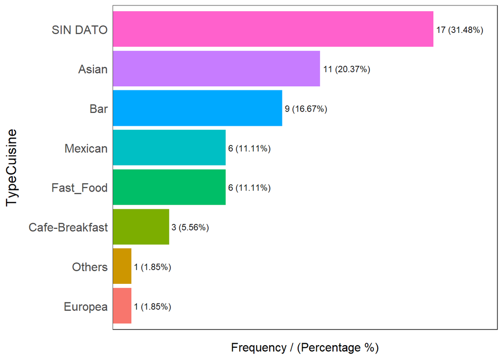

Se exportan los datos del resultado en un archivo csv para ser cargado a la base de datos del sistema que gestiona la pagina web.

```r
write.csv(allRestaurant,file="allRestaurantCSV.csv", row.names = FALSE)
```

### 5. Implementación

#### 5.1 ¿Cómo entiende que el modelo podría ser utilizado por la web para cumplir el objetivo funcional?

En función de lo transmitido en el requerimiento el usuario debería ingresar el nombre de un restaurante y el sitio web le devolvería los restaurantes similares en función del análisis de clusters realizado

#### 5.2 En base a lo anterior, ¿cómo debería ser la implementación de este modelo (estimación resultados en tiempo real, procesamiento batch, etc)?

Dentro de los tipos de implementación vistos en clase este modelo se podría clasificar como un análisis puntual que no precisa ser corrido con frecuencia. De todas formas sería importante cada cierto tiempo ir enriqueciendo las bases con información de los restaurantes y más aún cuando debimos trabajar solo con 130 registros por no contar con información relevante para los restantes.

Implementaremos el modelo a conectándonos con una base de datos y actualizando los resultados de las predicciones por ID cada vez que hay una nueva corrida. Se guardarán los resultados en un csv se realizará una conexión a la base de datos y guardaremos las predicciones de los modelos en una tabla y columna específica.

#### 5.3 ¿Cómo se podrían armar, usando los resultados de este modelo, los rankings de restoranes “en términos relativos” o “específicos a un grupo”? Si bien no es necesario realizar los desarrollos, identifique el proceso, actividades, variables a utilizar, etc y describa con el mayor detalle posible.

Los resultados del modelo se deberían mostrar en la web al ingresar el nombre de un restaurante por parte del usuario devolviendo todos los registros correspondientes a ese cluster. Entendemos que el cliente nos debería especificar el criterio para mostrar los restaurantes correspondientes a ese cluster pero sugerimos hacerlo por distancia de gower comenzado por la que tenga una menor, considerando que una menor distancia implica mayor similitud entre los mismos. Otro criterio de ordenamiento podría ser la ubicación geográfica, el tipo de comida recomendando en primer lugar los que ofrecen la misma comida que ingresó el usuario o por rating del restaurante.

#### 5.4 ¿Qué ventaja tendría esto frente a usar un ranking general?

En el caso de la distancia de gower por ejemplo, la ventaja es que si no conocemos específicamente el atributo que según el usuario hace que un restaurante sea similar a otro, este parámetro contempla todas las variables mejorando la probabilidad de devolver uno similar considerando todas las variables contenidas en el dataset. #### 5.5 ¿Cómo se podría evaluar el resultado (éxito) del trabajo? Más allá de los métodos estadísticos como la silueta que se muestra en el desarrollo del trabajo, a nivel de negocio sería importante conocer la opinión del usuario luego de haber concurrido al restaurante recomendado de forma de conocer el grado de satisfacción de la recomendación.